# HNRNPK motif enrichment

February 08, 2023

# Analysis question:

Are array-bound sequences also bound *in vivo*?

- See if highly bound sequences are enriched in ChIP-seq peaks
- hnRNPK ChIP-seq in HepG2 and K562 cells (from ENCODE project PMID: 32728246)

```r
library(dplyr)
library(purrr)
library(readr)
```

```r
file<-'counts/iMotif_array_v2_HNRNPK_motif_analysis.tsv'
data<-read.csv(file, sep='\t')
#glimpse(data)

# remove data without any occurrences in hg38
data<-data[data$hg38_occurrences >0,]

chiplen<-read.table('counts/seq_lengths.tsv',sep='\t',  col.names=c('sample','length'))
rownames(chiplen)<-chiplen$sample
rownames(chiplen)<-gsub('seq/','',rownames(chiplen))
rownames(chiplen)<-gsub('.stab','',rownames(chiplen))

#chiplen
```

## Enrichment metrics

Scan imotif probe sequence in hnRNPK peaks from these two cell lines

Two metrics:

1. fraction of motif occurrences in a ChIP-seq peak (count_in_peak/hg38 occurrences)
2. Enrichment score (He et al., GBE 2015): For each i-motif, we compute the observed occurrences $OCC_{obs}$ of each imotif in the ChIP-seq peaks. The expected occurrence, $OCC_{exp}$ is computed as:

$$OCC_{exp}=N\times\frac{L_r}{L_g},$$

where N is the number of occurrences in the genome, $L_r$ is the length of the observed regions, and $L_g$ is the length of the genome. Next, we compute an enrichment score, $E=\frac{OCC_{obs}}{OCC_{exp}}$. The significance of the enrichment is computed using a chi-squared test, and FDR adjusted p-values computed using the Benjamini-Hochberg method.

```r
data$frac.HNRNPK_HepG2<-data$count.HNRNPK_HepG2.ENCFF035OPG.merged / data$hg38_occurrences
data$frac.HNRNPK_K562<-data$count.HNRNPK_K562.ENCFF505RNR.merged / data$hg38_occurrences

data$Exp.HNRNPK_HepG2<-data$hg38_occurrences * (chiplen['HNRNPK_HepG2.ENCFF035OPG.merged',]$length/chiplen['hg38',]$length)
data$Exp.HNRNPK_K562<-data$hg38_occurrences * (chiplen['HNRNPK_K562.ENCFF505RNR.merged',]$length/chiplen['hg38',]$length)

data$Enrich.HNRNPK_HepG2 <- (data$count.HNRNPK_HepG2.ENCFF035OPG.merged) / (data$Exp.HNRNPK_HepG2)
data$Enrich.HNRNPK_K562 <-(data$count.HNRNPK_K562.ENCFF505RNR.merged) / (data$Exp.HNRNPK_K562)

peak_length<-chiplen['HNRNPK_HepG2.ENCFF035OPG.merged',]$length
genome_length<-chiplen['hg38',]$length


pvals<-matrix(0,nrow=(nrow(data)),ncol = 1)
colnames(pvals)<-'pvals.HNRNPK_HepG2'


adjpvals<-matrix(0,nrow=(nrow(data)),ncol = 1)

for ( g  in 1:nrow(data)){
  peak_occurrence<-data$count.HNRNPK_HepG2.ENCFF035OPG.merged[g]
  genome_occurrence<-data$hg38_occurrences[g]


  mytable<-matrix(c(peak_occurrence, genome_occurrence,peak_length-peak_occurrence,genome_length-genome_occurrence),ncol=2)
  xx<-chisq.test(mytable)
  pvals[g]<-xx$p.value
}
adjpvals<-p.adjust(pvals,method="BH")

pvals2<-matrix(0,nrow=(nrow(data)),ncol = 1)
colnames(pvals2)<-'pvals.HNRNPK_K562'

adjpvals2<-matrix(0,nrow=(nrow(data)),ncol = 1)


peak_length<-chiplen['HNRNPK_K562.ENCFF505RNR.merged',]$length
genome_length<-chiplen['hg38',]$length

for ( g  in 1:nrow(data)){
  peak_occurrence<-data$count.HNRNPK_K562.ENCFF505RNR.merged[g]
  genome_occurrence<-data$hg38_occurrences[g]
  mytable<-matrix(c(peak_occurrence, genome_occurrence,peak_length-peak_occurrence,genome_length-genome_occurrence),ncol=2)
  xx<-chisq.test(mytable)
  pvals2[g]<-xx$p.value
}
adjpvals2<-p.adjust(pvals2,method="BH")

data<-cbind(data,pvals,adjpvals,pvals2,adjpvals2)
data<- data %>%
  rename(adjpvals.HNRNPK_HepG2 = adjpvals,
        adjpvals.HNRNPK_K562 = adjpvals2
    )

write.table(data,"iMotif_array_v2_HNRNPK_motif_analysis.enrichment_scores.tab", sep="\t", row.names=F, quote=F)
```

## Data summary

```r
mysubset<-data[,c('UniqueID', 'TrimmedSeq_rev', 'hnRNPK_rep','frac.HNRNPK_HepG2','Enrich.HNRNPK_HepG2','adjpvals.HNRNPK_HepG2','frac.HNRNPK_K562','Enrich.HNRNPK_K562','adjpvals.HNRNPK_K562')]

mysubset[is.na(mysubset)] <-0

mysubset<- mysubset %>%
  rename('Sequence' = 'TrimmedSeq_rev',
        'adjP.HNRNPK_HepG2' = 'adjpvals.HNRNPK_HepG2',
        'adjP.HNRNPK_K562'='adjpvals.HNRNPK_K562')

mysubset %>%
  DT::datatable(rownames = F)%>%
  DT::formatRound(columns=c('Enrich.HNRNPK_HepG2','Enrich.HNRNPK_K562','frac.HNRNPK_HepG2','frac.HNRNPK_K562','adjP.HNRNPK_HepG2','adjP.HNRNPK_K562'), digits=2)
```

| UniqueID | Sequence | hnRNPK_rep | frac.HNRNPK_HepG2 | Enrich.HNRNPK_HepG2 | adjP.HNRNPK_HepG2 | frac.HNRNPK_K562 | Enrich.HNRNPK_K562 | adjP.HNRNPK_K562 |
| --- | --- | --- | --- | --- | --- | --- | --- | --- |
| V2_IMOTIF_11170 | CCAAAATGTGTGTGGGTTTCTCCTCACTAACGACCAGTTCTCC | -0.37 | 0 | 0 | 0.999999999999369 | 0 | 0 | 0.999999999998845 |
| V2_IMOTIF_11112 | CCTGCGGGGCTGTGCCTTCTCGCCTGGCTGCCTCC | -0.205 | 0 | 0 | 0.999999999999369 | 0 | 0 | 0.999999999998845 |
| V2_IMOTIF_10865 | CCGTGTCCATCTCCTGTGGCGCC | -0.07 | 0 | 0 | 0.999999999999369 | 0 | 0 | 0.999999999998845 |
| V2_IMOTIF_10816 | CCACCTTCTCCACGGGGTAGACGGCTTCCACCTAGTGGCAGATGAGCC | -0.33 | 0 | 0 | 0.999999999999369 | 0 | 0 | 0.999999999998845 |
| V2_IMOTIF_455 | CCTGCAGAACCATGAGCCAATTAAACCTGTTTTCTTTATAAATTACC | -0.18 | 0 | 0 | 0.999999999999369 | 0 | 0 | 0.999999999998845 |
| V2_IMOTIF_10811 | CCTGCGCCGCTTCCTGCAGAAGCGGCCGGGAGCC | -0.4 | 0 | 0 | 0.999999999999369 | 1 | 617.311555469126 | 2.46906025623485e-17 |
| V2_IMOTIF_10901 | CCGCCTCCTTTCTTCTCGGCC | 9.83 | 1 | 295.789354910421 | 1.0542256912487e-08 | 0 | 0 | 0.999999999998845 |
| V2_IMOTIF_11057 | CCTCCAGATCCACTCC | 5.59 | 0.142857142857143 | 42.2556221300602 | 0.0211667192119752 | 0 | 0 | 0.999999999998845 |
| V2_IMOTIF_10851 | CCTCTTTTCCTGAGCTCTGCCGCC | 2.135 | 0 | 0 | 0.999999999999369 | 0 | 0 | 0.999999999998845 |
| V2_IMOTIF_10800 | CCACTGGTCTCCACTCCTCACCTGCAAAGAGCC | -0.12 | 0 | 0 | 0.999999999999369 | 0 | 0 | 0.999999999998845 |

[output cut: 11110 more lines]

## Enrichment summary

What proportion of well-bound sequences on the array are significantly enriched (adjP<0.05) in ChIP-seq peaks?

```r
nHepG2<- length(which(mysubset$adjP.HNRNPK_HepG2<0.05))
nK562 <- length(which(mysubset$adjP.HNRNPK_K562<0.05))

cutoffs<-seq(5,40,5)
num_sig <- data.frame(SNR_Threshold = paste0(">",cutoffs))
num_sig$SNR_Threshold <-factor(num_sig$SNR_Threshold, levels=c(paste0(">",cutoffs)))

print(paste0("Num significantly enriched seqs HepG2: ", nHepG2))
```

```
## [1] "Num significantly enriched seqs HepG2: 2055"
```

```r
print(paste0("Num significantly enriched seqs K562: ", nK562))
```

```
## [1] "Num significantly enriched seqs K562: 1179"
```

```r
num_sig$ArraySeq <-
  unlist(lapply(cutoffs,
                function(x) {
                  length(which(mysubset$hnRNPK_rep > x))
                  }
                )
         )


num_sig$HepG2_sig <-
  unlist(lapply(cutoffs,
                function(x) {
                  length(which(mysubset$hnRNPK_rep > x & mysubset$adjP.HNRNPK_HepG2<0.05))
                  }
                )
         )




num_sig$HepG2_prct<-paste0(round(num_sig$HepG2_sig / num_sig$ArraySeq*100,2),"%")

# Is proportion significant?
# compute hypergeometric pvalue
# phyper(q, m, n, k, lower.tail = FALSE, log.p = FALSE)
#  q = well bound and sig. enriched in vivo -1
#  m = number of enriched sequences
#  n = array sequences - not enriched in vivo
#  k = sample size:  well bound sequences
#  use:  lower.tail=FALSE:  if TRUE (default), probabilities are P[X <= x], otherwise, P[X > x]


num_sig$HepG2_hgPval <-
  unlist(lapply(cutoffs,
                function(x) {
                  phyper(length(which(mysubset$hnRNPK_rep > x & mysubset$adjP.HNRNPK_HepG2<0.05))-1,
                         nHepG2,
                         nrow(mysubset)-nHepG2,
                         length(which(mysubset$hnRNPK_rep > x)),
                         lower.tail=FALSE)
                  }
                )
         )

num_sig$K562_sig <-
  unlist(lapply(cutoffs,
                function(x) {
                  length(which(mysubset$hnRNPK_rep > x & mysubset$adjP.HNRNPK_K562<0.05))
                  }
                )
         )

num_sig$K562_prct<-paste0(round(num_sig$K562_sig / num_sig$ArraySeq * 100,2),"%")


num_sig$K562_hgPval <-
  unlist(lapply(cutoffs,
                function(x) {
                  phyper(length(which(mysubset$hnRNPK_rep > x & mysubset$adjP.HNRNPK_K562<0.05))-1,
                         nK562,
                         nrow(mysubset)-nK562,
                         length(which(mysubset$hnRNPK_rep > x)),
                         lower.tail=FALSE)
                  }
                )
         )

num_sig %>%
DT::datatable(
              rownames = F,
              options = list(
            columnDefs = list(list(className = 'dt-center', targets = 0:3))
            )
          ) %>%
DT::formatSignif(columns = c('HepG2_hgPval', 'K562_hgPval'), digits = 3)
```

| SNR_Threshold | ArraySeq | HepG2_sig | HepG2_prct | HepG2_hgPval | K562_sig | K562_prct | K562_hgPval |
| --- | --- | --- | --- | --- | --- | --- | --- |
| &gt;5 | 8319 | 1712 | 20.58% | 1.71706061935061e-24 | 981 | 11.79% | 1.96447129731726e-13 |
| &gt;10 | 5999 | 1358 | 22.64% | 3.87019672589757e-35 | 791 | 13.19% | 2.31907985406137e-22 |
| &gt;15 | 3612 | 887 | 24.56% | 1.4629285487369e-29 | 517 | 14.31% | 3.9314988130861e-18 |
| &gt;20 | 1846 | 494 | 26.76% | 2.93740761128338e-22 | 279 | 15.11% | 2.45191379562075e-11 |
| &gt;25 | 933 | 265 | 28.4% | 6.02638343936146e-15 | 141 | 15.11% | 5.14398925547116e-06 |
| &gt;30 | 414 | 118 | 28.5% | 2.59504541494669e-07 | 65 | 15.7% | 0.000724481384411658 |
| &gt;35 | 187 | 60 | 32.09% | 4.72656002551139e-06 | 34 | 18.18% | 0.00115198466869154 |
| &gt;40 | 88 | 31 | 35.23% | 0.000139259501911756 | 22 | 25% | 9.34927090845444e-05 |

## Enrichment summary – figure

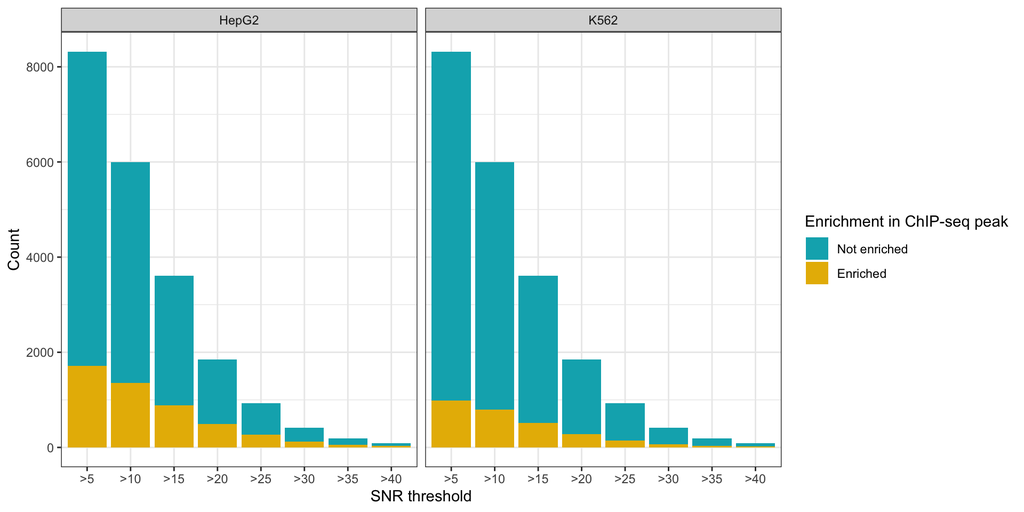

```r
library(tidyverse)
library(viridis)

# plot hepG2
pdata<-num_sig[,c(1:3,6)]
pdata$HepG2_nsig<-pdata$ArraySeq-pdata$HepG2_sig
pdata$K562_nsig<-pdata$ArraySeq-pdata$K562_sig

lpdata<-pivot_longer(pdata,cols=c(3:ncol(pdata)),names_to =c("Enrichment"),values_to="Count")
lpdata <- separate_wider_delim(lpdata, Enrichment, "_", names=c("CellType","Enrichment"))
lpdata$Enrichment <- gsub("nsig","Not enriched",lpdata$Enrichment)
lpdata$Enrichment <- gsub("sig","Enriched",lpdata$Enrichment)
lpdata$Enrichment <-factor(lpdata$Enrichment, levels=c("Not enriched","Enriched"))



ggplot(lpdata, aes(fill=Enrichment,x=SNR_Threshold, y=Count)) +
  geom_bar(position="stack", stat="identity") +
  theme_bw() +
  scale_fill_manual(values=c("#00AFBB","#E7B800")) +
  facet_grid(cols=vars(CellType)) +
  ylab("Count") +
  labs(fill="Enrichment in ChIP-seq peak") +
  xlab("SNR threshold")
```

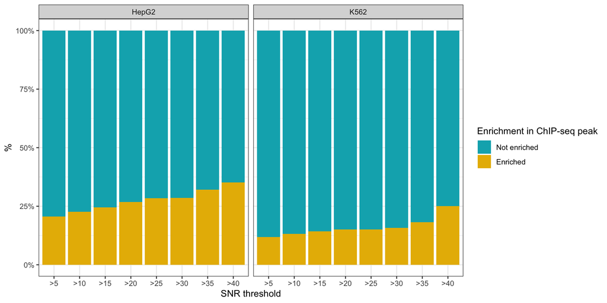

```r
ggsave("imotif_invivo_enrichment.bar.count.pdf")

ggplot(lpdata, aes(fill=Enrichment,x=SNR_Threshold, y=Count)) +
  geom_bar(position="fill", stat="identity") +
  theme_bw() +
  scale_fill_manual(values=c("#00AFBB","#E7B800")) +
  scale_y_continuous(labels = scales::percent) +
  facet_grid(cols=vars(CellType)) +
  ylab("%") +
  labs(fill="Enrichment in ChIP-seq peak") +
  xlab("SNR threshold")
```

```r
ggsave("imotif_invivo_enrichment.bar.prct.pdf")
```